# Rein v3 - Usikkerhet i bestandstall

# Start

Dette er en felles indikator for villrein og tamreinsbestander Utarbeidelsen av metodikken er gjort av Erik Fremstad. I denne varsjonen av indikatoren legger vi til en usikkerhet i bestandsestimatet - litt større for villrein enn for tamrein. Det er usikkert hvor presist dette er, men man kan gjerne tolke usikkerhet til også å omfavne usikkerheten i referanseverdien

# Import

Datasett med bestandstall, areal, og TRIverdier. Topographic roughenss index brukes til å modellere referansetilstand. For hvert reinområde andgis areal per region.

```r
dat <- read_excel("../data/rein.xlsx")
head(dat)
```

```
## # A tibble: 6 × 13
##   type   navn  navn2 Totalreal fjellareal bestand `TRI-fjell`     E      S     W
##   <chr>  <chr> <chr>     <dbl>      <dbl>   <dbl>       <dbl> <dbl>  <dbl> <dbl>
## 1 Villr… Sete… Sete…     7067.     5119.     3500        364.  NA   3212.  1907.
## 2 Villr… Sete… Sete…     2433.      660.     2000        437.  NA    660.    NA
## 3 Villr… Skau… Skau…      654.      604.       60        573.  NA     NA    604.
## 4 Villr… Våmu… Våmu…      449.       51.2     240        382.  NA     51.2   NA
## 5 Villr… Brat… Brat…      417.      213.      500        326.  NA    213.    NA
## 6 Villr… Blef… Blef…      264.       64.4     140        324.  29.2   35.2   NA
## # … with 3 more variables: C <dbl>, N <dbl>, totalt <dbl>
```

Kolonnen med total areal (helt til høyre) stemmer nesten med total fjellareal, så jeg kan bruke de vekselsvis.

Rydder

```r
dat <- dplyr::select(dat, -navn2)
```

Så setter jeg alle NA til 0. Dette inkluderer totalbestand for Trollheimen. Trollheimen har tom celle for totalbestand. Siden det er skrevet 0 i cellen for fjellbestand så antar jeg det skal være null i den andre også.

```r
dat[is.na(dat)] <- 0
```

Fordeling av areal mellom regioner.

```r
dat$propN <- dat$N/dat$totalt
dat$propC <- dat$C/dat$totalt
dat$propE <- dat$E/dat$totalt
dat$propW <- dat$W/dat$totalt
dat$propS <- dat$S/dat$totalt
```

# Melt

Nå deler jeg opp villreinområdene i så mange regioner som de inngår i

```r
setDT(dat)
dat2 <- melt(dat,
             measure.vars = c("N", "C", "E", "W", "S"),
             value.name = "area",
             variable.name= "reg",
             na.rm=T)
```

Dette gir fem rader per område. Så tar jeg bort de radene der det ikke finnes noe (fjell)areal

```r
temp <- dat2[dat2$type=="ingen rein",]
dat2 <- dat2[dat2$area>0,]
dat2 <- rbind(dat2, temp)
rm(temp)
```

Det er noen rader med type = ingen rein som vi må kombinere på et vis.

```r
temp <- dat2[dat2$type=="ingen rein",]
dat2 <- dat2[dat2$type!="ingen rein",]
```

```r
temp2 <- temp[temp$navn == "Fjell uten rein - nord" &
                temp$reg %in% c("N"),]

temp3 <- temp[temp$navn == "Fjell uten rein - sør" &
                temp$reg %in% c("E", "S", "W", "C"),]

temp4 <- temp[temp$navn =="Fjellområder uten rein",]
temp4 <- temp4[!duplicated(temp4$reg)]

temp <- rbind(temp2, temp3)
temp$area <- temp4$area[match(temp$reg, temp4$reg)]
```

```r
dat2 <- rbind(dat2, temp)
```

Så kan jeg regne ut referansetettheter.

```r
dat2$ref <- 0.75*1.0759*exp(-0.001*dat2$`TRI-fjell`)
```

Så legger jeg på en usikkerhet rundt betsnadsestimatene. 10%CV for villrein og 5%CV for tamrein.

Her er de observerte dyretetthetene. Siden tettheten er antatt lik i fjell og ikke-fjell trenger vi ikke gå veien innom å regne ut bestandstall

```r
dat2$tetthet <- dat2$bestand/dat2$Totalreal
#Endrer NaN til 0
dat2$tetthet[dat2$type=="ingen rein"] <- 0

dat2$ID <- paste0(dat2$navn, dat2$reg)
```

Jeg legger på en CV på 10% for villrein og 5% for tamrein. Dette gir en spredning i verdier som ser slik ut:

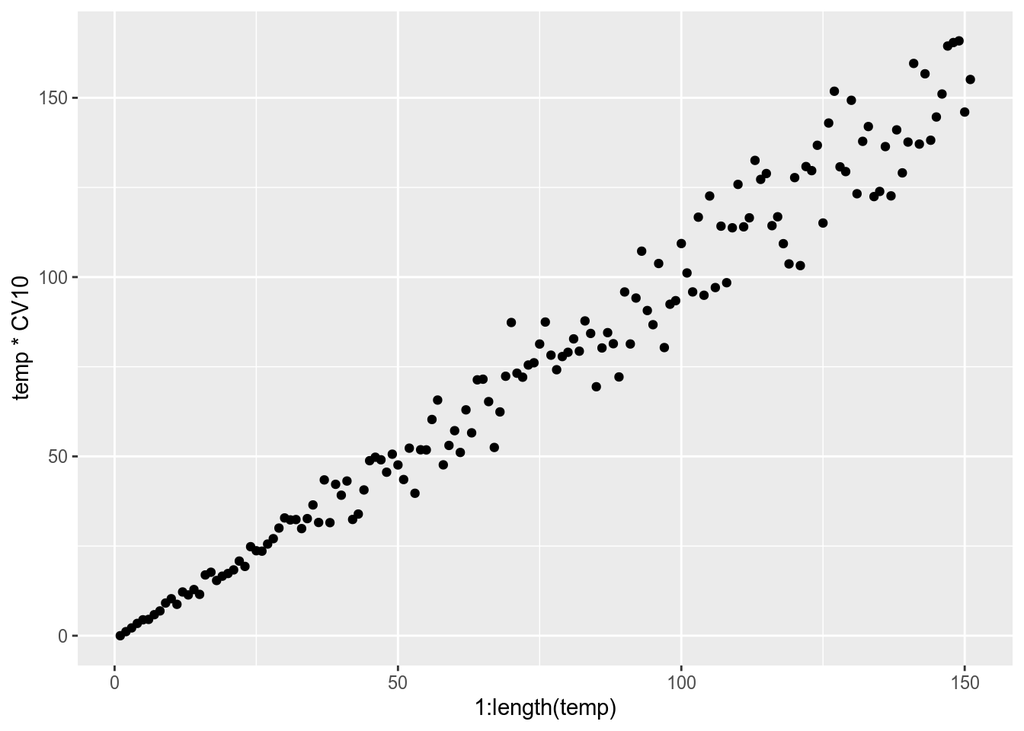

```r
temp <- seq(0,150, 1)
CV10 <- rnorm(150, 1, .1)
ggplot()+
  geom_point(mapping = aes(y = temp*CV10,
                           x = 1:length(temp)))
```

```r
nsim <- 1000
refs <- c()
IDs <- c()
reg <- c()
area <- c()
ind <- c()
indtemp <- c()

for(i in dat2$ID){
  temp <- dat2[dat2$ID == i,]

  ifelse(temp$type == "Tamrein",
           temp2 <- rnorm(nsim, 1, 0.05),
           temp2 <- rnorm(nsim, 1, 0.1))

  indtemp <- (temp$bestand/temp$Totalreal)*temp2
  IDs <- c(IDs, rep(i, nsim))
  refs <- c(refs, rep(temp$ref, nsim))
  reg <- c(reg, rep(as.character(temp$reg), nsim))
  area <- c(area, rep(temp$area, nsim))
  ind <- c(ind, indtemp)
}
```

```r
sims <- data.table(
  reg = reg,
  ID = IDs,
  area = area,
  refs = refs,
  ind = ind)
```

Det blir NaN der vi har null rein.

```r
unique(sims$ID[sims$ind== "NaN"])
```

```
## [1] "Fjell uten rein - nordN" "Fjell uten rein - sørC"
## [3] "Fjell uten rein - sørE"  "Fjell uten rein - sørW"
## [5] "Fjell uten rein - sørS"
```

Disse kan vi sette til null.

```r
sims$ind[sims$ind == "NaN"] <- 0
```

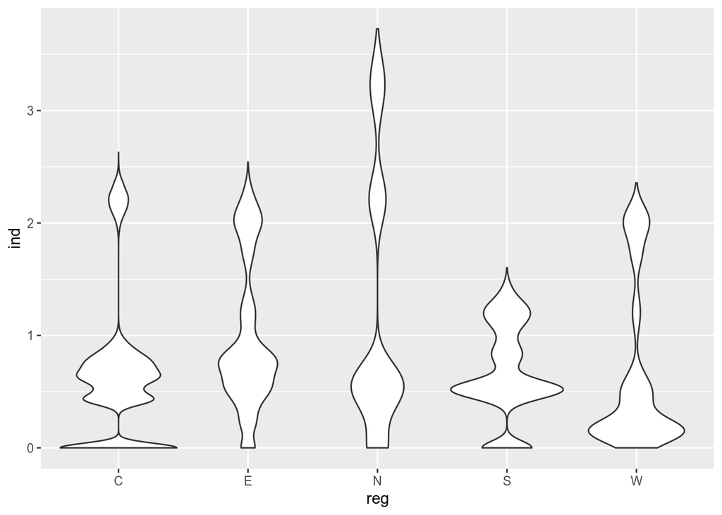

```r
ggplot(data = sims, aes(x = reg, y = ind))+
  geom_violin()
```

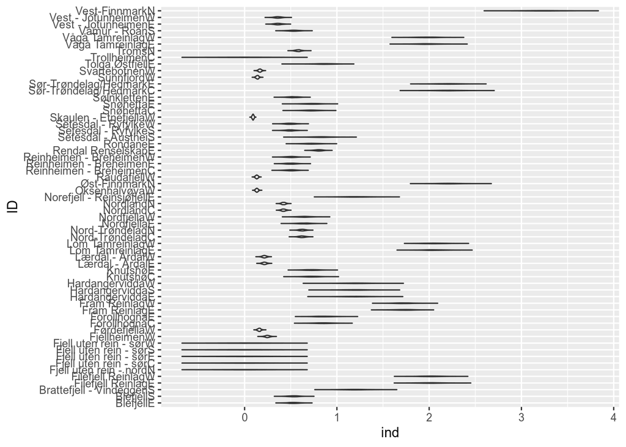

```r
ggplot(data = sims, aes(x = ID, y = ind))+
  geom_violin(trim=F)+
  coord_flip()
```

```r
summary(sims$ind)
```

```
##    Min. 1st Qu.  Median    Mean 3rd Qu.    Max.
##  0.0000  0.2897  0.6078  0.8336  1.1702  3.7272
```

Det ser bra ut. Variasjonen øker når gjennomsnittet øker.

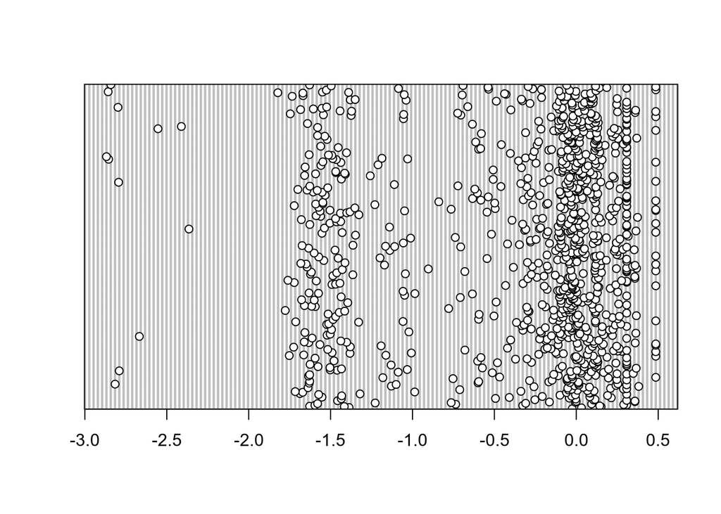

```r
sims$diff <- sims$ref-sims$ind
dotchart(sample(sims$diff, 1000, replace = F))
```

Her må vi ha en tosidig skalering. Erik har laget et forslag til skalering som ser slik ut

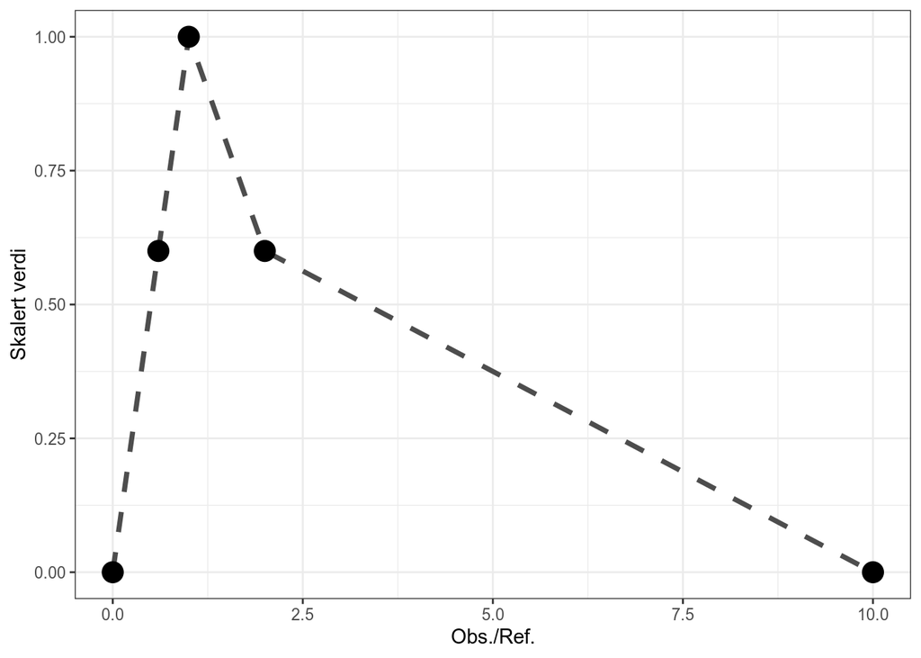

```r
temp <- data.frame(x = c(0, 0.6, 1, 2,10),
                   y = c(0, 0.6, 1, 0.6, 0))

(mod <- ggplot(data = temp, aes(x = x, y = y))+
  geom_line(size=1.3, linetype="dashed", colour="grey30")+
  geom_point(size=5)+
  theme_bw()+
  ylab("Skalert verdi")+
  xlab("Obs./Ref.")
)
```

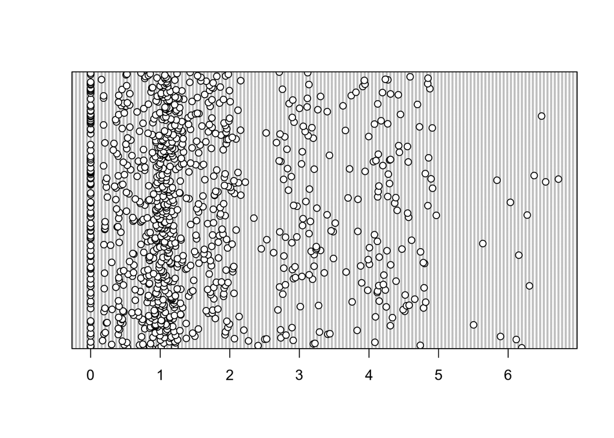

```r
sims$rat <- sims$ind/sims$ref
dotchart(sample(sims$rat, 1000, replace = F))
```

```r
rm(dat2, dat)
```

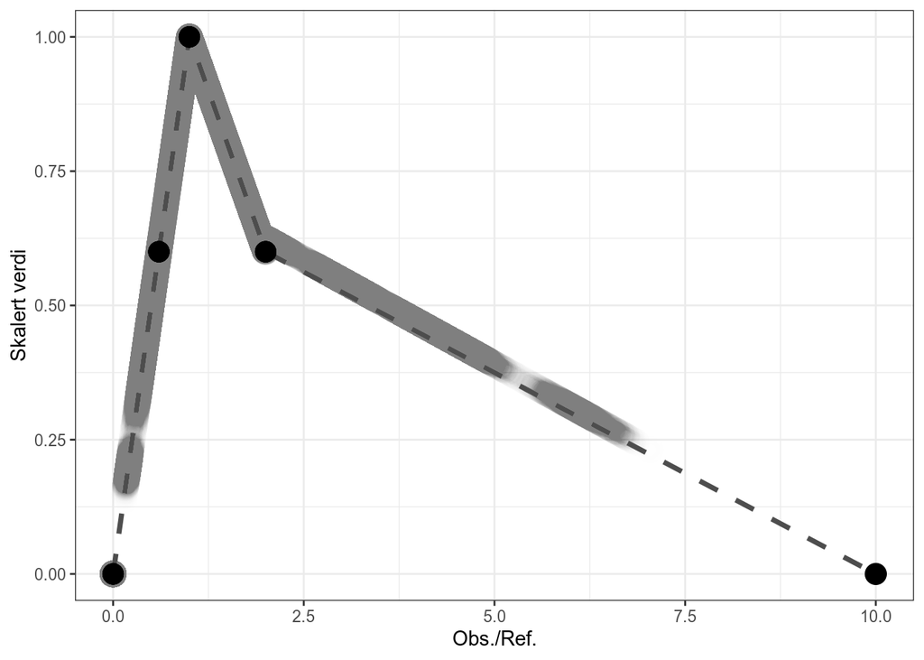

```r
sims$val <- NA
sims$val[sims$rat<1]                 <- sims$rat[sims$rat<1]
sims$val[sims$rat %between% c(1, 2)] <- 1-(0.4*((sims$rat[sims$rat %between% c(1, 2)])-1))
sims$val[sims$rat >2]                <- (1-((sims$rat[sims$rat >2]-2)/(10-2)))/1.6

(mod + geom_point(data=sims, aes(x = rat, y = val),
                  size=3, alpha=.005, stroke=3))
```

```r
summary(sims$val)
```

```
##    Min. 1st Qu.  Median    Mean 3rd Qu.    Max.
##  0.0000  0.4578  0.6672  0.6425  0.9218  1.0000
```

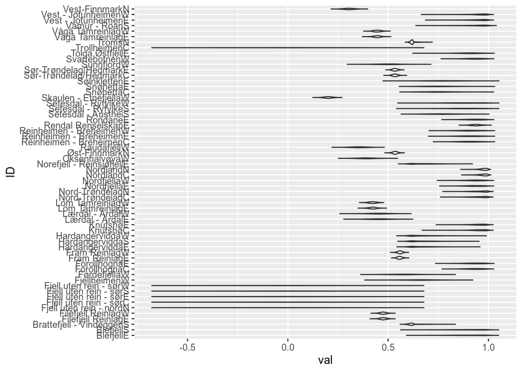

```r
ggplot(data = sims, aes(x = ID, y = val))+
  geom_violin(trim=F)+
  coord_flip()
```

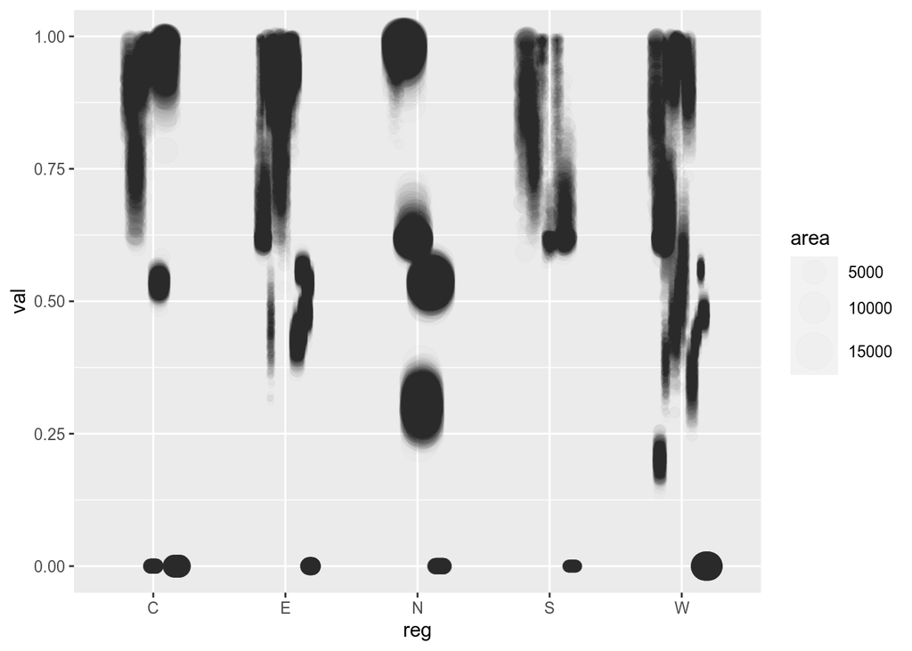

```r
ggplot(data = sims, aes(x = reg, y = val))+
  geom_point(position = position_dodge2(0.4),
             aes(size = area),
             alpha = 0.01)+
 scale_size_continuous(range = c(1, 10))
```

Fint. Så trenger jeg et arealvektet gjennomsnitt per region. Bruker 100*500 resamplings.

```r
nsim <- 500
vals <- c()
reg <- c()
temp2 <- c()


for(i in unique(sims$reg)){

  temp <- sims[sims$reg==i,]

  for(i in 1:nsim){
    temp3 <- c()
    wgt   <- c()

  for(m in 1:100){

    temp2 <- temp[runif(1,0,nrow(temp)),]
    temp3 <- c(temp3, temp2$val)
    wgt   <-  c(wgt, temp2$area)
  }
    vals <- c(vals, weighted.mean(temp3, wgt))
    reg <- c(reg, temp$reg[1])
  }
}

df <- data.frame(reg = reg,
                 val = vals,
                 year = 2020,
                 X = "rein")
```

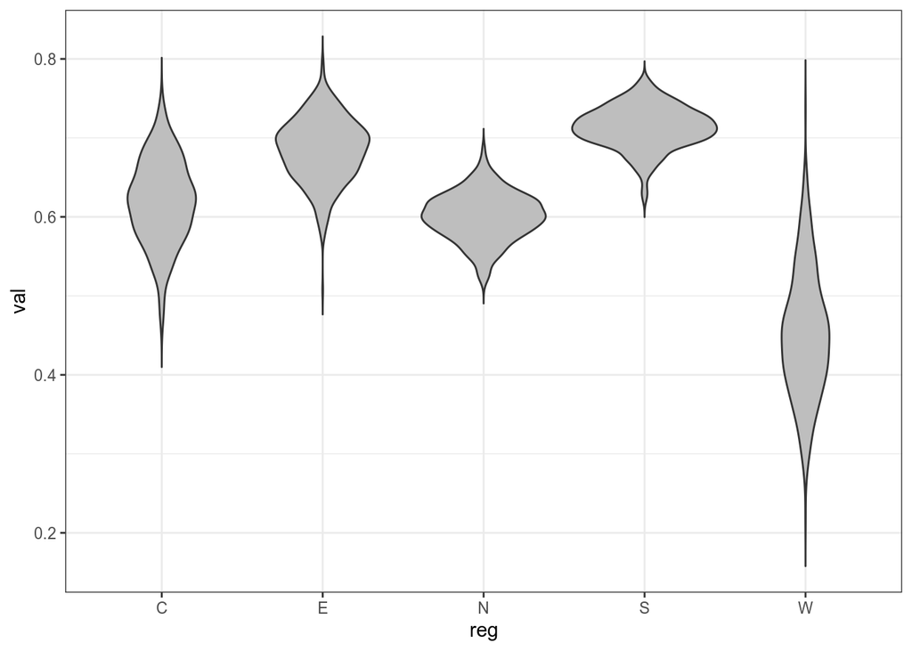

```r
ggplot(data = df, aes(x = reg, y = val))+
  geom_violin(trim=F, fill="grey")+
  theme_bw()
```

Så må vi ha en verdi for hele Norge Fjellareal per region:

```r
wgt <- readRDS("../data/fjellareal.rds")
wgt$Fjellareal2 <- wgt$Fjellareal/max(wgt$Fjellareal)
wgt$reg <- c("N", "C", "E", "W", "S")
```

```r
regions <- c("N", "C", "W", "S", "E")



temp <- c()
temp2 <- c()


for(i in 1:1000){

temp <- c(
      sample(df$val[df$reg == "N"], 1),
      sample(df$val[df$reg == "C"], 1),
      sample(df$val[df$reg == "E"], 1),
      sample(df$val[df$reg == "W"], 1),
      sample(df$val[df$reg == "S"], 1)
    )

temp2 <- c(temp2, weighted.mean(temp, wgt$Fjellareal2))

}


Norge <- data.frame(
  reg = rep("Norge", 1000),
  val = temp2,
  year = 2020,
  X = "rein"
)
df <- rbind(df, Norge)
```

```r
df$reg <- as.factor(df$reg)
```

# Plotting

```r
temp2 <- c("N", "C", "E", "S", "W", "Norge")
temp3 <- c("Nord-Norge", "Midt-Norge", "Østlandet", "Sørlandet", "Vestlandet", "Norge")
```

```r
df2 <- df

df <- aggregate(data = df,
                val~reg,
                FUN = function(x) c(quantile(x, c(0.025, .5, 0.975))))
df <- do.call(data.frame, df)
names(df) <- c("reg", "low", "med", "upp")
```

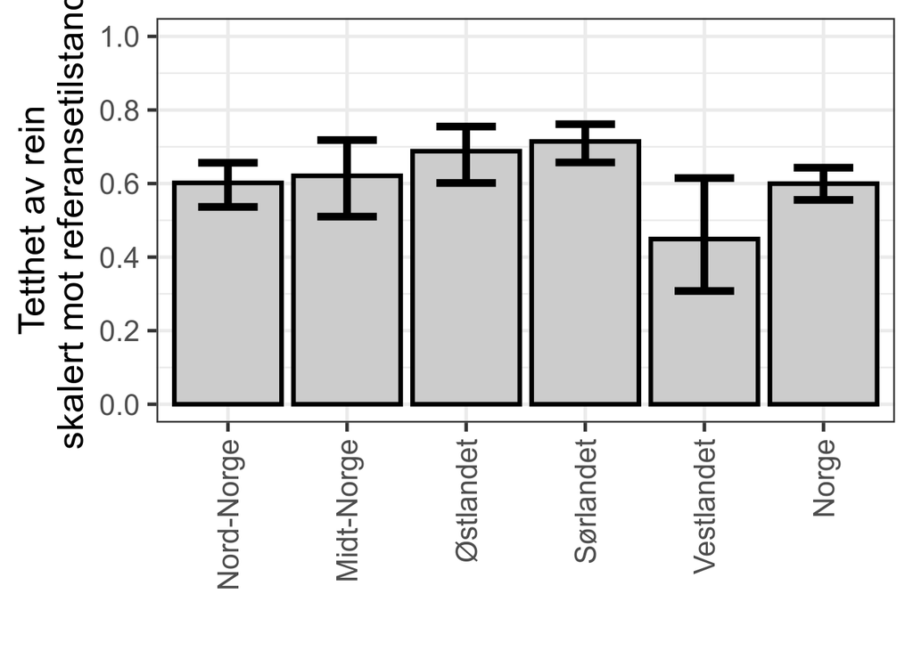

```r
(gg <- ggplot(data = df, aes(x = factor(reg, levels = temp2), y = med))+
  geom_bar(stat="identity", colour="black", size=1.2,
           fill="grey80")+
  geom_errorbar(aes(ymax = upp, ymin=low), width=.5, size=2)+
  theme_bw(base_size = 20)+
  ylab("Tetthet av rein\nskalert mot referansetilstand")+
  xlab("")+
  theme(
    axis.text.x = element_text(angle = 90, vjust = 0.5, hjust=1)
  )+
   scale_x_discrete(breaks = temp2,
                    labels = temp3)+
   scale_y_continuous(breaks = seq(0,1,.2),
                      limits = c(0,1))
)
```

```r
png("../output/indicatorPlots/skalert/rein.png",
    units="in", width=6, height=8, res=300)
gg
dev.off()
```

```r
write.csv(df2, "../output/indicator_values/rein.csv", row.names = F)
```